# Enteropathogen antibody dynamics and force of infection among children in low-resource settings

Haiti incidence analysis, Table 2

# Notebook Summary

This script estimates the incidence rate of seroconversion and seroreversion in the Haitian cohort. It also estimates the incidence rate of antibody boosting and waning events, defined as a 4-fold change in antibody levels to above a seropositivity cutoff (boosting) or from above a seropositivity cutoff (waning).

# Script preamble

```r
#-----------------------------
# preamble
#-----------------------------
library(here)
here::here()
```

```
## [1] "/Users/benarnold/enterics-seroepi"
```

```r
# load packages
library(tidyverse)
library(kableExtra)

# set up for parallel computing
# configure for a laptop (use only 3 cores)
library(foreach)
library(doParallel)
registerDoParallel(cores=3)

# bright color blind palette:  https://personal.sron.nl/~pault/
cblack <- "#000004FF"
cblue <- "#3366AA"
cteal <- "#11AA99"
cgreen <- "#66AA55"
cchartr <- "#CCCC55"
cmagent <- "#992288"
cred <- "#EE3333"
corange <- "#EEA722"
cyellow <- "#FFEE33"
cgrey <- "#777777"

# safe color blind palette
# http://jfly.iam.u-tokyo.ac.jp/color/
# http://www.cookbook-r.com/Graphs/Colors_(ggplot2)/
cbPalette <- c("#999999", "#E69F00", "#56B4E9", "#009E73", "#F0E442", "#0072B2", "#D55E00", "#CC79A7")
```

```r
#-----------------------------
# load the formatted data
# created with
# haiti-enteric-ab-data-format.Rmd
#-----------------------------
dl <- readRDS(here::here("data","haiti_analysis2.rds"))
```

# Identify incident changes

Among children, identify those that changed status between enrollment and follow-up. Those who changed from negative to positive are seroconverters (`seroi` below), and those who changed from positive to negative are seroreverters (`seror` below).

```r
#-----------------------------
# identify seropositive measures
# hierarchy of information for
# cutoffs:
# 1. ROC
# 2. mixture model based
# 3. estimated among presumed unexposed
#
# store the cutoff value used
# for figures
#-----------------------------
dl <- dl %>%
  mutate(seropos=ifelse(!is.na(posroc),posroc,posmix),
         serocut=ifelse(!is.na(posroc),roccut,mixcut),
         serocut_desc=ifelse(!is.na(posroc),"ROC","Mixture Model")) %>%
  mutate(seropos=ifelse(!is.na(seropos),seropos,posunex),
         serocut_desc=ifelse(!is.na(serocut),serocut_desc,"Unexp dist"),
         serocut=ifelse(!is.na(serocut),serocut,unexpcut))
```

# Seroincidence estimates

Estimates of the mean seroincidence rates. The rates assume that incident sero-conversions and sero-reversions happened at the mid-point between measurements for each child.

As with the age-prevalence curve analysis, use information across multiple recombinant antigens for each pathogen when identifying risk periods and incident seroconversions and seroreversions.

```r
#-----------------------------
# Identify incident boosting/waning
# of 4-fold MFI or more. For
# incident boosting, +4fold increase
# that ends above seropositivity cutoff
# for incident waning, -4fold decrease
# that starts above seropositivity cutoff
#-----------------------------
dl2 <- dl %>%
  group_by(antigenf,id) %>%
  arrange(antigenf,id,age) %>%
  mutate(nobs=n(),obsnum=row_number(),
         agediff=ifelse(obsnum==1,lead(age)-age,age-lag(age)),

    logmfi_lag  = lag(logmfi),
    logmfi_lead = lead(logmfi),
    logmfi_dlag  = logmfi - logmfi_lag,
    logmfi_dlead = logmfi_lead - logmfi,
    logmfi_d4fold = ifelse(logmfi_dlag>log10(4),1,0),
    # incident boosting based on a 4-fold increase in MFI
    # with a second measure above the seropositivity cutoff
    seroi4fold = ifelse(logmfi_dlag>log10(4) & logmfi>serocut,1,0),
    seroi4fold = ifelse(is.na(logmfi_dlag),NA,seroi4fold),
    # incident waning based on a 4-fold decrease in MFI
    # with the first measure above the seropositivity cutoff
    seror4fold = ifelse(logmfi_dlag< -log10(4) & logmfi_lag>serocut,1,0)
         ) %>%
  ungroup()
```

```r
#-----------------------------
# create composite
# seroprevalence, boosting,
# and waning indicators
# that use information from
# multiple antigens if available
#-----------------------------
dl3 <- dl2 %>%
  ungroup() %>%
  mutate(pathogen2=as.character(pathogen),
         pathogen2=ifelse(antigenf=="Norovirus GI.4","Norovirus GI.4",pathogen2),
         pathogen2=ifelse(antigenf=="Norovirus GII.4.NO","Norovirus GII.4.NO",pathogen2))%>%
  group_by(pathogen2,id,obsnum) %>%
  select(pathogen=pathogen2,id,obsnum,age,agediff,seropos,seroi4fold,seror4fold) %>%
  # since incidence could fall at slightly different times across the antigens
  # for the same pathogen, use the earlier onset as the incidence measure
  arrange(pathogen,id,obsnum) %>%
  group_by(pathogen,id) %>%
  mutate(lagseroi=lag(seroi4fold),
         seroi4fold=ifelse(seroi4fold==1 & lagseroi==1 & !is.na(lagseroi),0,seroi4fold)) %>%
  # since incidence could fall at slightly different times across the antigens
  # for the same pathogen, use the later onset as the incident measure
  mutate(leadseror=lead(seror4fold),
         seror4fold=ifelse(seror4fold==1 & leadseror==1 & !is.na(leadseror),0,seror4fold)) %>%
  # now get the max for each pathogen at each timepoint
  group_by(pathogen,id,obsnum) %>%
  mutate(seropos=max(seropos),
         seroi4fold=max(seroi4fold),
         seror4fold=max(seror4fold)
         ) %>%
  slice(1) %>%
  mutate(antigenf = case_when(
    pathogen == "Giardia" ~ "Giardia VSP-3 or VSP-5",
    pathogen == "Cryptosporidium" ~ "Cryptosporidium Cp17 or Cp23",
    pathogen == "E. histolytica" ~ "E. histolytica LecA",
    pathogen == "Salmonella" ~ "Salmonella LPS groups B or D",
    pathogen == "ETEC" ~ "ETEC LT B subunit",
    pathogen == "Norovirus GI.4" ~ "Norovirus GI.4",
    pathogen == "Norovirus GII.4.NO" ~ "Norovirus GII.4.NO"),
    antigenf=factor(antigenf,levels=c("Giardia VSP-3 or VSP-5",
                                  "Cryptosporidium Cp17 or Cp23",
                                  "E. histolytica LecA",
                                  "Salmonella LPS groups B or D",
                                  "ETEC LT B subunit",
                                  "Norovirus GI.4",
                                  "Norovirus GII.4.NO"))
  ) %>%
  select(pathogen,antigenf,id,age,obsnum,seropos,seroi4fold,seror4fold)

#----------------------------
# there were 7 chilren that
# had a +4-fold increase in
# one crypto antigen and a
# 4-fold decrease in another
# at the same measurement
# this is unusual. In these
# seven cases, set the
# incident waning indicator to 0
#----------------------------
table(dl3$seroi4fold,dl3$seror4fold)
```

```
##
##        0    1
##   0 3013  571
##   1  812    7
```

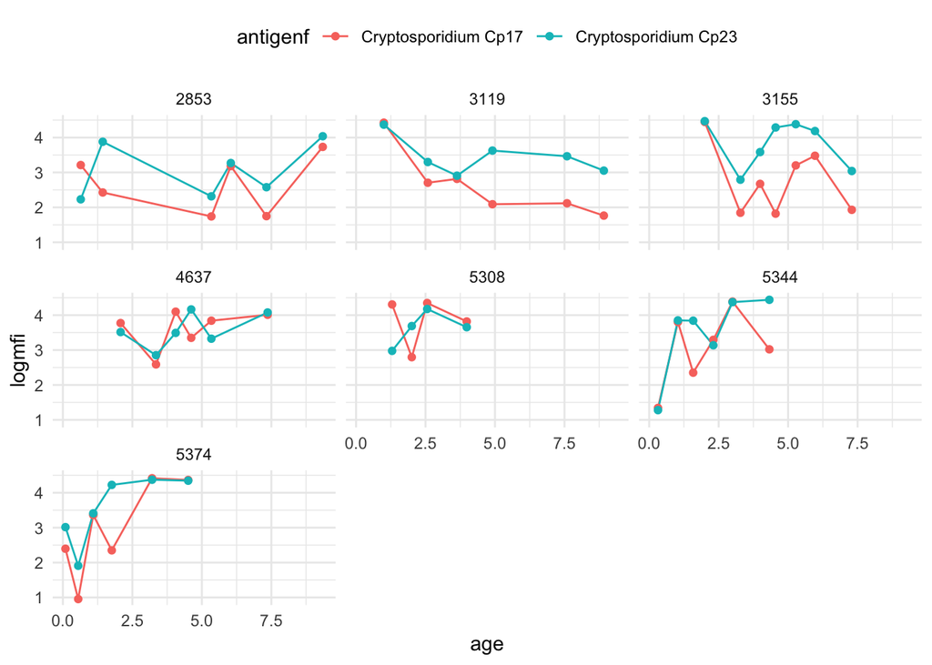

```r
indivp <- ggplot(data=filter(dl,
                             id %in% c(2853,3119,3155,4637,5308,5344,5374) &
                               antigen %in% c("cp17","cp23")),
                 aes(x=age,y=logmfi,id=factor(id),color=antigenf)) +
  geom_line() +
  geom_point()+
  facet_wrap(~id,ncol=3) +
  theme_minimal() +
  theme(legend.position="top")
indivp
```

```r
dl3 <- dl3 %>%
  mutate(seror4fold=ifelse(seroi4fold==1 & seror4fold==1,0,seror4fold))
table(dl3$seroi4fold,dl3$seror4fold)
```

```
##
##        0    1
##   0 3013  571
##   1  819    0
```

```r
#-----------------------------
# identify incident
# seroconversions and reversions
#-----------------------------

# group the data by child and
# use lags to identify
# time in years between measurements,
# sero-conversions + sero-reversions
# between measurements
# set the first measurement to
# missing for the incidence indicators
# (using the is.na(age_diff) to identify them)
dl4 <- dl3 %>%
  group_by(antigenf,id) %>%
  arrange(antigenf,id,obsnum) %>%
  mutate(age_min  = min(age),
         agediff = age - lag(age),

         # incident seroconversions and reversions
         # including cumulative numbers
         # based on crossing seropositivity cutoff
         seropos_lag  = lag(seropos),
         seroi = ifelse(seropos==1 & seropos_lag==0,1,0),
         seroi = ifelse(is.na(agediff),NA,seroi),
         seroin = cumsum(ifelse(is.na(seroi),0,seroi)),
         seroin = ifelse(seroi==1,seroin,0),
         seror = ifelse(seropos==0 & seropos_lag==1,1,0),
         seror = ifelse(is.na(agediff),NA,seror),
         serorn = cumsum(ifelse(is.na(seror),0,seror)),
         serorn = ifelse(seror==1,serorn,0)
         ) %>%
  select(
         id,obsnum,
         starts_with("age"),
         antigenf,
         seropos,seroi,seroin,seror,serorn,
         seroi4fold,seror4fold,
         -seropos_lag)
```

## Seroincidence rates based on seropositivity cutoff

```r
#-----------------------------
# estimate sero-incidence rates
# for conversion and reversion
# estimate SEs with a bootstrap
#-----------------------------

#-----------------------------
# estimate time at risk
# for seroconversion and reversion
# assumed to be 1/2 of time
# between measurements
# if indivs are seropositive
# at measurement 1 they are
# not at risk for seroconversion
# (and vice-versa for seroreversion)
#-----------------------------
dl5 <- dl4 %>%
  mutate(ptc = ifelse(seropos==0,agediff,0),
         ptc = ifelse(seropos==1 & seroi==1,agediff/2,ptc),
         ptr = ifelse(seropos==1 & seroi==0,agediff,0),
         ptr = ifelse(seropos==0 & seror==1,agediff/2,ptr))

#-----------------------------
# estimate incidence rates
# for each antibody
# units are episodes per child-year
#-----------------------------
rate_ests <- dl5 %>%
  group_by(antigenf) %>%
  summarize(ni=sum(seroi,na.rm=T),
            nit=sum(ptc,na.rm=T),
            nr=sum(seror,na.rm=T),
            nrt=sum(ptr,na.rm=T)) %>%
  mutate(seroi=ni/nit,
         seror=nr/nrt)

#-----------------------------
# get bootstrap CIs
# resampling children with
# replacement due to repeated
# measures
#-----------------------------
dboot <- dl5 %>%
  group_by(antigenf) %>%
  select(id,antigenf,seroi,seror,ptc,ptr) %>%
  mutate(id=as.character(id))

set.seed(123)
nreps <- 1000
ids <- unique(dboot$id)
bsamp <- matrix(sample(ids,size=length(ids)*nreps,replace=TRUE),
                nrow=length(ids),ncol=nreps)
bootests <- foreach(ab=levels(dboot$antigenf),.combine=rbind) %:%
  foreach(brep=1:nreps,.combine=rbind) %dopar% {
    di <- dboot %>% filter(antigenf==ab)
    di <- left_join(data.frame(id=bsamp[,brep]),di,by=c("id")) %>%
      select(-id) %>% group_by(antigenf) %>%
      summarize_all(function(x) sum(x,na.rm=TRUE))
    }

rate_cis <- bootests %>%
  group_by(antigenf) %>%
  mutate(sero_c=seroi/ptc,sero_r=seror/ptr) %>%
  # restrict to finite values (some ETEC bootstrap replicates have a denominator of 0)
  summarize(seroi_lb = quantile(sero_c[is.finite(sero_c)],probs=c(0.025),na.rm=T),
            seroi_ub = quantile(sero_c[is.finite(sero_c)],probs=c(0.975),na.rm=T),
            seror_lb = quantile(sero_r[is.finite(sero_r)],probs=c(0.025),na.rm=T),
            seror_ub = quantile(sero_r[is.finite(sero_r)],probs=c(0.975),na.rm=T)
            )

rate_ests <- left_join(rate_ests,rate_cis,by="antigenf") %>%
  select(antigenf,ni,nit,starts_with("seroi"),nr,nrt,starts_with("seror"))
```

Confirm bootstrap distributions of the rates are smooth and reasonable

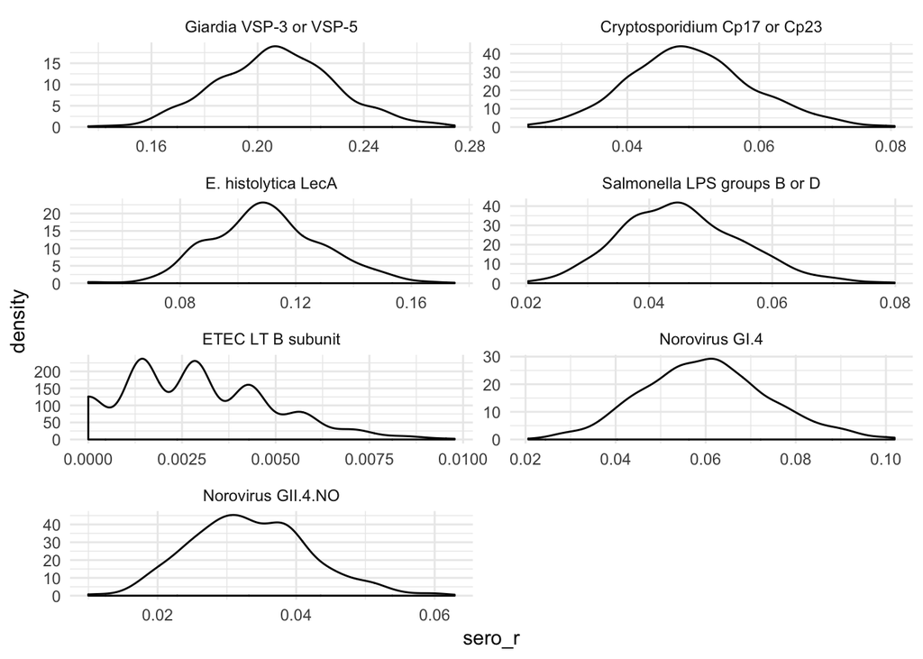

```r
bsum <- bootests %>%
  group_by(antigenf) %>%
  mutate(sero_c=seroi/ptc,sero_r=seror/ptr)

ggplot(data=bsum,aes(x=sero_r)) + geom_density() + facet_wrap(~antigenf,ncol=2,scales="free") + theme_minimal()
```

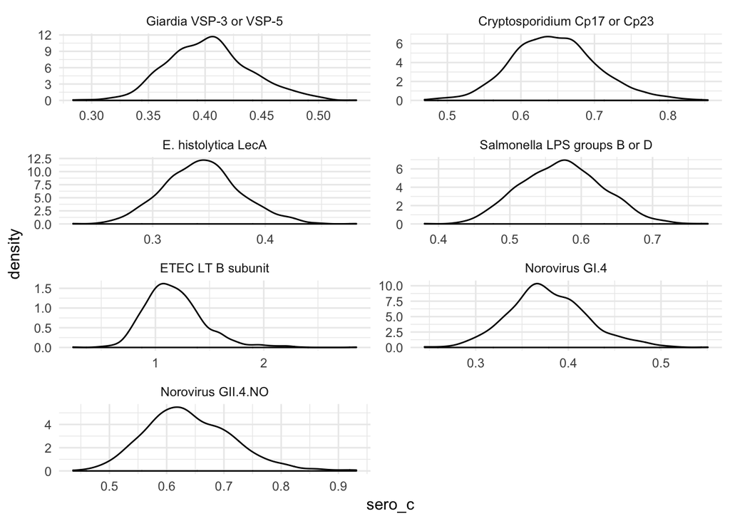

```r
ggplot(data=bsum,aes(x=sero_c)) + geom_density() + facet_wrap(~antigenf,ncol=2,scales="free") + theme_minimal()
```

Tables of results

```r
rate_ests %>%
  select(antigenf,nit,ni,starts_with("seroi")) %>%
  knitr::kable(digits=2,
             caption="Incidence rates of seroconversion per child year",
             col.names = c("Antigen","Years at risk","n events","Incidence per year","min95","max95"),
             row.names = FALSE) %>%
  kable_styling(bootstrap_options = c("striped"),full_width = TRUE)
```

Incidence rates of seroconversion per child year

| Antigen | Years at risk | n events | Incidence per year | min95 | max95 |
| --- | --- | --- | --- | --- | --- |
| Giardia VSP-3 or VSP-5 | 269.57 | 108 | 0.40 | 0.34 | 0.48 |
| Cryptosporidium Cp17 or Cp23 | 109.35 | 70 | 0.64 | 0.54 | 0.77 |
| E. histolytica LecA | 283.71 | 97 | 0.34 | 0.28 | 0.42 |
| Salmonella LPS groups B or D | 132.07 | 75 | 0.57 | 0.47 | 0.68 |
| ETEC LT B subunit | 9.72 | 11 | 1.13 | 0.75 | 1.82 |
| Norovirus GI.4 | 213.01 | 80 | 0.38 | 0.30 | 0.47 |
| Norovirus GII.4.NO | 105.82 | 67 | 0.63 | 0.51 | 0.80 |

```r
rate_ests %>%
  select(antigenf,nrt,nr,starts_with("seror")) %>%
  knitr::kable(digits=2,
             caption="Incidence rates of seroreversion per child year",
             col.names = c("Antigen","Years at risk","n events","Incidence per year","min95","max95"),
             row.names = FALSE) %>%
  kable_styling(bootstrap_options = c("striped"),full_width = TRUE)
```

Incidence rates of seroreversion per child year

| Antigen | Years at risk | n events | Incidence per year | min95 | max95 |
| --- | --- | --- | --- | --- | --- |
| Giardia VSP-3 or VSP-5 | 441.60 | 91 | 0.21 | 0.17 | 0.25 |
| Cryptosporidium Cp17 or Cp23 | 586.15 | 29 | 0.05 | 0.03 | 0.07 |
| E. histolytica LecA | 395.22 | 43 | 0.11 | 0.08 | 0.15 |
| Salmonella LPS groups B or D | 544.29 | 25 | 0.05 | 0.03 | 0.07 |
| ETEC LT B subunit | 702.11 | 2 | 0.00 | 0.00 | 0.01 |
| Norovirus GI.4 | 464.89 | 28 | 0.06 | 0.03 | 0.09 |
| Norovirus GII.4.NO | 574.35 | 19 | 0.03 | 0.02 | 0.05 |

## Seroincidence rates based on 4-fold change

```r
#-----------------------------
# estimate sero-incidence rates
# for antibody boosting and waning
# estimate SEs with a bootstrap
#-----------------------------

#-----------------------------
# estimate time at risk
# for seroconversion and reversion
# assumed to be 1/2 of time
# between measurements
# if indivs seroconvert
#
# create indicators of at risk
# based on incidence boosting
# and waning
# at risk if seronegative OR experienced
# a 4-fold decrease in MFI in previous period
#
# the below code is opaque, but confirmed through
# extensive vetting and inspection that it does this:
# children are at risk of boosting if they are seronegative or
# if they experience a 4-fold decrease in MFI between the previous
# two measurements
#-----------------------------
dl6 <- dl4 %>%
  mutate(seroi4fold=ifelse(obsnum==1,0,seroi4fold),
         seror4fold=ifelse(obsnum==1,0,seror4fold),
         maxobs=max(obsnum),
         # seronegative at obs 1: at risk
         # seropositive at obs 1: not at risk
         cntr = 0,
         cntr = ifelse(seroi4fold==1 & lag(seroi4fold)==0,-1,0), # counter -1 if first +4
         cntr = ifelse(obsnum==1 & seropos==0,1,cntr), # counter +1 if seroneg&obs1
         cntr = ifelse(seror4fold==1,1,cntr), # counter +1 if seror
         cntr = ifelse(seror4fold==1 & seropos==0 & lag(cntr)==1,cntr-1,cntr),

         # sum counter to help with recodes below
         cntrs = cumsum(cntr),

         cntr = ifelse(obsnum!=maxobs & lead(cntr)==-1 & lead(cntrs)==-1,1,cntr),
         cntr = ifelse(obsnum!=maxobs & lead(cntr)==-1 & lead(cntrs)==-2,1,cntr),
         cntr = ifelse(seror4fold==1 & cntrs==2,0,cntr),

         # indicator of whether a chlid is at risk for seroconversion
         atrisk = cumsum(cntr),
         atrisk = lag(atrisk),

         # fix a very small number of idiosyncratic situations
         # that don't fit neatly into the above algorithm (n=5)
         atrisk = ifelse(obsnum==1,0,atrisk),
         atrisk = ifelse(obsnum > 2 & atrisk==2 | lag(atrisk==2),atrisk-1,atrisk),

         # now calculate person time at risk for conversion and reversion
         atriskc = atrisk,
         atriskr = 1-atrisk,
         ptc = ifelse(atriskc==1,agediff,0),
         ptc = ifelse(atriskc==1 & seroi4fold==1,agediff/2,ptc),
         ptr = ifelse(atriskr==1,agediff,0),
         ptr = ifelse(atriskr==1 & seror4fold==1,agediff/2,ptr)

  )


#-----------------------------
# estimate incidence rates
# for each antibody
# units are episodes per child-year
#-----------------------------
rate_ests_4fold <- dl6 %>%
  group_by(antigenf) %>%
  summarize(ni=sum(seroi4fold,na.rm=T),
            nit=sum(ptc,na.rm=T),
            nr=sum(seror4fold,na.rm=T),
            nrt=sum(ptr,na.rm=T)) %>%
  mutate(seroi=ni/nit,seror=nr/nrt)

#-----------------------------
# get bootstrap CIs
# resampling children with
# replacement due to repeated
# measures
#-----------------------------
dboot <- dl6 %>%
  group_by(antigenf) %>%
  select(id,antigenf,seroi4fold,seror4fold,ptc,ptr) %>%
  mutate(id=as.character(id))

set.seed(123)
nreps <- 1000
ids <- unique(dboot$id)
bsamp <- matrix(sample(ids,size=length(ids)*nreps,replace=TRUE),
                nrow=length(ids),ncol=nreps)
bootests <- foreach(ab=levels(dboot$antigenf),.combine=rbind) %:%
  foreach(brep=1:nreps,.combine=rbind) %dopar% {
    di <- dboot %>% filter(antigenf==ab)
    di <- left_join(data.frame(id=bsamp[,brep]),di,by=c("id")) %>%
      select(-id) %>% group_by(antigenf) %>%
      summarize_all(function(x) sum(x,na.rm=TRUE))
    }

rate_cis <- bootests %>%
  group_by(antigenf) %>%
  mutate(sero_c=seroi4fold/ptc,sero_r=seror4fold/ptr) %>%
  # restrict to finite values (some ETEC bootstrap replicates have a denominator of 0)
  summarize(seroi_lb = quantile(sero_c[is.finite(sero_c)],probs=c(0.025),na.rm=T),
            seroi_ub = quantile(sero_c[is.finite(sero_c)],probs=c(0.975),na.rm=T),
            seror_lb = quantile(sero_r[is.finite(sero_r)],probs=c(0.025),na.rm=T),
            seror_ub = quantile(sero_r[is.finite(sero_r)],probs=c(0.975),na.rm=T)
            )

rate_ests_4fold <- left_join(rate_ests_4fold,rate_cis,by="antigenf") %>%
  select(antigenf,ni,nit,starts_with("seroi"),nr,nrt,starts_with("seror"))
```

Confirm bootstrap distributions of the rates are smooth and reasonable

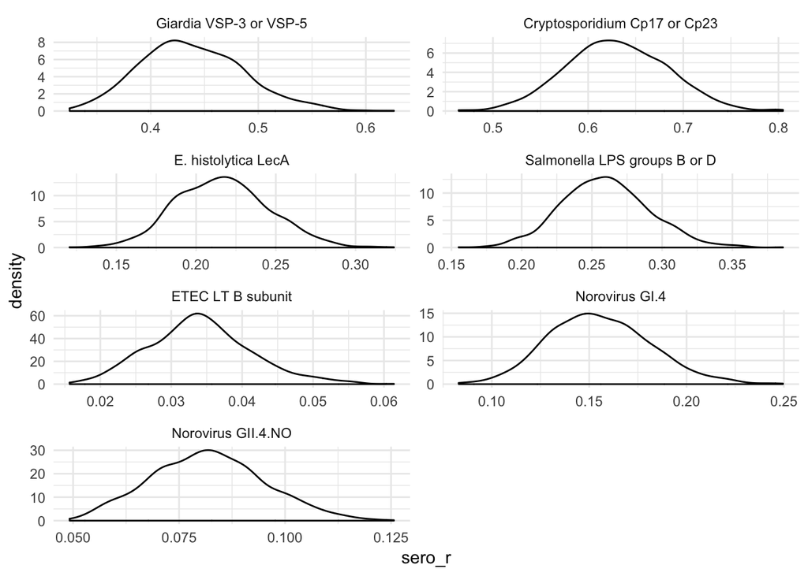

```r
bsum <- bootests %>%
  group_by(antigenf) %>%
  mutate(sero_c=seroi4fold/ptc,sero_r=seror4fold/ptr)

ggplot(data=bsum,aes(x=sero_r)) + geom_density() + facet_wrap(~antigenf,ncol=2,scales="free") + theme_minimal()
```

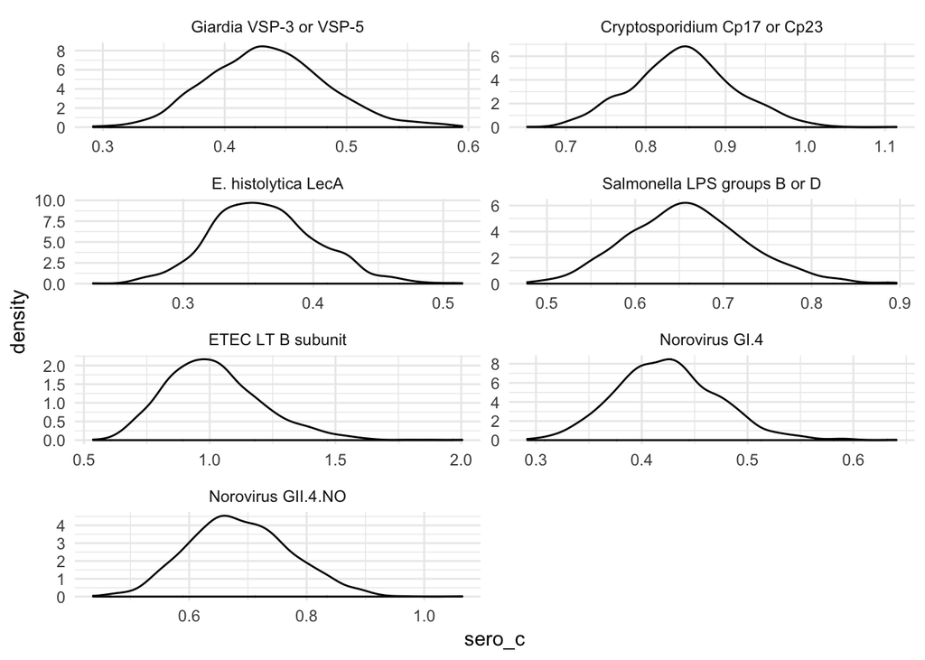

```r
ggplot(data=bsum,aes(x=sero_c)) + geom_density() + facet_wrap(~antigenf,ncol=2,scales="free") + theme_minimal()
```

Table of results

```r
rate_ests_4fold %>%
  select(antigenf,nit,ni,starts_with("seroi")) %>%
  knitr::kable(digits=2,
             caption="Incidence rates of 4-fold antibody boosting per child year",
             col.names = c("Antigen","Years at risk","n events","Incidence per year","min95","max95"),
             row.names = FALSE) %>%
  kable_styling(bootstrap_options = c("striped"),full_width = TRUE)
```

Incidence rates of 4-fold antibody boosting per child year

| Antigen | Years at risk | n events | Incidence per year | min95 | max95 |
| --- | --- | --- | --- | --- | --- |
| Giardia VSP-3 or VSP-5 | 277.18 | 120 | 0.43 | 0.35 | 0.54 |
| Cryptosporidium Cp17 or Cp23 | 240.99 | 204 | 0.85 | 0.73 | 0.97 |
| E. histolytica LecA | 297.06 | 107 | 0.36 | 0.29 | 0.45 |
| Salmonella LPS groups B or D | 226.80 | 149 | 0.66 | 0.54 | 0.80 |
| ETEC LT B subunit | 32.06 | 32 | 1.00 | 0.70 | 1.45 |
| Norovirus GI.4 | 254.26 | 107 | 0.42 | 0.34 | 0.53 |
| Norovirus GII.4.NO | 147.19 | 100 | 0.68 | 0.54 | 0.86 |

```r
rate_ests_4fold %>%
  select(antigenf,nrt,nr,starts_with("seror")) %>%
  knitr::kable(digits=2,
             caption="Incidence rates of 4-fold antibody waning per child year",
             col.names = c("Antigen","Years at risk","n events","Incidence per year","min95","max95"),
             row.names = FALSE) %>%
  kable_styling(bootstrap_options = c("striped"),full_width = TRUE)
```

Incidence rates of 4-fold antibody waning per child year

| Antigen | Years at risk | n events | Incidence per year | min95 | max95 |
| --- | --- | --- | --- | --- | --- |
| Giardia VSP-3 or VSP-5 | 290.85 | 127 | 0.44 | 0.35 | 0.54 |
| Cryptosporidium Cp17 or Cp23 | 273.49 | 171 | 0.63 | 0.53 | 0.74 |
| E. histolytica LecA | 310.44 | 67 | 0.22 | 0.16 | 0.27 |
| Salmonella LPS groups B or D | 344.53 | 89 | 0.26 | 0.20 | 0.32 |
| ETEC LT B subunit | 649.73 | 22 | 0.03 | 0.02 | 0.05 |
| Norovirus GI.4 | 362.18 | 56 | 0.15 | 0.11 | 0.21 |
| Norovirus GII.4.NO | 477.94 | 39 | 0.08 | 0.06 | 0.11 |

# Table 2

Create a single table to summarize and compare incidence rates by the two methods

```r
tab1 <- rate_ests %>%
  mutate(seroiests1 = paste(sprintf("%1.2f",seroi)," (",sprintf("%1.2f",seroi_lb),", ",sprintf("%1.2f",seroi_ub),")",sep=""),
         serorests1 = paste(sprintf("%1.2f",seror)," (",sprintf("%1.2f",seror_lb),", ",sprintf("%1.2f",seror_ub),")",sep="") ) %>%
  select(antigenf,ni1=ni,nit1=nit,seroi1=seroi,seroiests1,nr1=nr,nrt1=nrt,seror1=seror,serorests1)

tab2 <- rate_ests_4fold %>%
  mutate(seroiests2 = paste(sprintf("%1.2f",seroi)," (",sprintf("%1.2f",seroi_lb),", ",sprintf("%1.2f",seroi_ub),")",sep=""),
         serorests2 = paste(sprintf("%1.2f",seror)," (",sprintf("%1.2f",seror_lb),", ",sprintf("%1.2f",seror_ub),")",sep="") ) %>%
  select(antigenf,ni2=ni,nit2=nit,seroi2=seroi,seroiests2,nr2=nr,nrt2=nrt,seror2=seror,serorests2)

# join estimates and calculate percent change
dtab <- left_join(tab1,tab2,by=c("antigenf")) %>%
  mutate(ratioi = sprintf("%1.1f",seroi2/seroi1),
         ratioic = sprintf("%1.1f",ni2/ni1),
         ratior = sprintf("%1.1f",seror2/seror1),
         ratiorc = sprintf("%1.1f",nr2/nr1)
  )

# reshape long (stack) seroconversion and seroreversion
dtabi <- dtab %>%
  select(antigenf,nt1=nit1,n1=ni1,rate1=seroiests1,nt2=nit2,n2=ni2,rate2=seroiests2,ratiocase=ratioic,ratiorate=ratioi) %>%
  mutate(ratedesc="Seroconversion")

dtabr <- dtab %>%
  select(antigenf,nt1=nrt1,n1=nr1,rate1=serorests1,nt2=nrt2,n2=nr2,rate2=serorests2,ratiocase=ratiorc,ratiorate=ratior) %>%
  mutate(ratedesc="Seroreversion")

dtablong <- bind_rows(dtabi,dtabr) %>% select(ratedesc,everything())


knitr::kable(select(dtablong,-ratedesc),digits=1,
             caption="Incidence rates of seroconversion and seroreversion per child year among children ages 0-11 years in Haiti, 1990-1999. ",
             col.names = c("Pathogen","Child-years", "Incident cases","Rate (95% CI)","Child-years", "Incident cases","Rate (95% CI)","Ratio of cases","Ratio of rates")) %>%
  kable_styling(bootstrap_options = c("striped"),full_width = TRUE) %>%
  add_header_above(c(" " = 1, "Seropositivity cutoff *" = 3, "4 Fold Change in IgG levels †" = 3, " " = 2)) %>%
  group_rows("Seroconversion / boosting", 1,7) %>%
  group_rows("Seroreversion / waning", 8, 14) %>%
  footnote(symbol = c("Incident changes in serostatus defined by crossing seropositivity cutoffs.","Incident changes in serostatus defined by a 4-fold increase or decrease in IgG levels (MFI-bg), with incident boosting episodes restricted to changes that ended above the seropositivity cutoff and incident waning episodes restricted to changes that started from above the seropositivity cutoff.")
           )
```

Incidence rates of seroconversion and seroreversion per child year among children ages 0-11 years in Haiti, 1990-1999.

| Pathogen | Seropositivity cutoff * Child-years | Seropositivity cutoff * Incident cases | Seropositivity cutoff * Rate (95% CI) | 4 Fold Change in IgG levels † Child-years | 4 Fold Change in IgG levels † Incident cases | 4 Fold Change in IgG levels † Rate (95% CI) | Ratio of cases | Ratio of rates |
| --- | --- | --- | --- | --- | --- | --- | --- | --- |
| **Seroconversion / boosting** |  |  |  |  |  |  |  |  |
| Giardia VSP-3 or VSP-5 | 269.6 | 108 | 0.40 (0.34, 0.48) | 277.2 | 120 | 0.43 (0.35, 0.54) | 1.1 | 1.1 |
| Cryptosporidium Cp17 or Cp23 | 109.3 | 70 | 0.64 (0.54, 0.77) | 241.0 | 204 | 0.85 (0.73, 0.97) | 2.9 | 1.3 |
| E. histolytica LecA | 283.7 | 97 | 0.34 (0.28, 0.42) | 297.1 | 107 | 0.36 (0.29, 0.45) | 1.1 | 1.1 |
| Salmonella LPS groups B or D | 132.1 | 75 | 0.57 (0.47, 0.68) | 226.8 | 149 | 0.66 (0.54, 0.80) | 2.0 | 1.2 |
| ETEC LT B subunit | 9.7 | 11 | 1.13 (0.75, 1.82) | 32.1 | 32 | 1.00 (0.70, 1.45) | 2.9 | 0.9 |
| Norovirus GI.4 | 213.0 | 80 | 0.38 (0.30, 0.47) | 254.3 | 107 | 0.42 (0.34, 0.53) | 1.3 | 1.1 |
| Norovirus GII.4.NO | 105.8 | 67 | 0.63 (0.51, 0.80) | 147.2 | 100 | 0.68 (0.54, 0.86) | 1.5 | 1.1 |
| **Seroreversion / waning** |  |  |  |  |  |  |  |  |
| Giardia VSP-3 or VSP-5 | 441.6 | 91 | 0.21 (0.17, 0.25) | 290.9 | 127 | 0.44 (0.35, 0.54) | 1.4 | 2.1 |
| Cryptosporidium Cp17 or Cp23 | 586.1 | 29 | 0.05 (0.03, 0.07) | 273.5 | 171 | 0.63 (0.53, 0.74) | 5.9 | 12.6 |
| E. histolytica LecA | 395.2 | 43 | 0.11 (0.08, 0.15) | 310.4 | 67 | 0.22 (0.16, 0.27) | 1.6 | 2.0 |
| Salmonella LPS groups B or D | 544.3 | 25 | 0.05 (0.03, 0.07) | 344.5 | 89 | 0.26 (0.20, 0.32) | 3.6 | 5.6 |
| ETEC LT B subunit | 702.1 | 2 | 0.00 (0.00, 0.01) | 649.7 | 22 | 0.03 (0.02, 0.05) | 11.0 | 11.9 |
| Norovirus GI.4 | 464.9 | 28 | 0.06 (0.03, 0.09) | 362.2 | 56 | 0.15 (0.11, 0.21) | 2.0 | 2.6 |
| Norovirus GII.4.NO | 574.3 | 19 | 0.03 (0.02, 0.05) | 477.9 | 39 | 0.08 (0.06, 0.11) | 2.1 | 2.5 |

* Incident changes in serostatus defined by crossing seropositivity cutoffs.  
† Incident changes in serostatus defined by a 4-fold increase or decrease in IgG levels (MFI-bg), with incident boosting episodes restricted to changes that ended above the seropositivity cutoff and incident waning episodes restricted to changes that started from above the seropositivity cutoff.

# Compare seroincidence rates with seroprevalence

For pathogens without seroreversion, age-dependent seroprevalence is a measure of the cumulative distribution of exposure. In turn, this is a measure of the cumulative incidence of seroconversion. Since the seroreversion rate was substantial for many pathogens studied, we would hypothesize there would not necessarily be a strong relationship between seroprevalence and the average seroincidence rate over the age period. Examine this relationship for each pathogen.

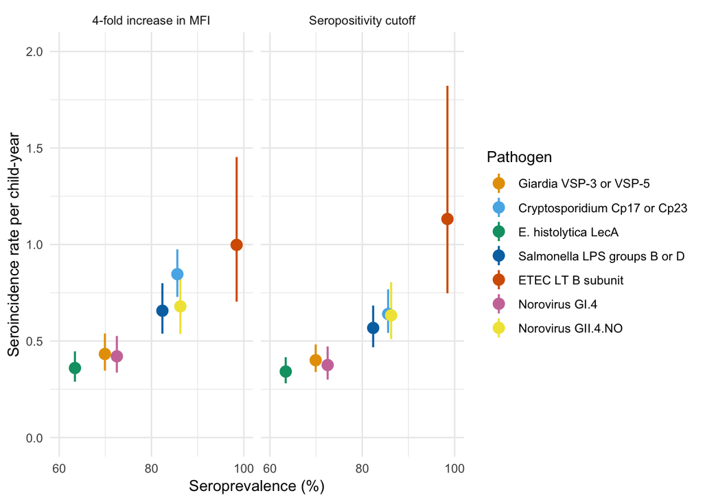

```r
serop <- dl6 %>%
  group_by(antigenf) %>%
  summarize(seroprev=mean(seropos))

d_seropi <- left_join(rate_ests,serop,by="antigenf") %>%
  mutate(method="Seropositivity cutoff")
d_serop4fold <- left_join(rate_ests_4fold,serop,by="antigenf")  %>%
  mutate(method="4-fold increase in MFI")

d_serop <- bind_rows(d_seropi,d_serop4fold) %>%
  mutate(method=factor(method))

# custom color blind color palette is in the preamble chunck
pcols <- cbPalette[c(2:4,6:8,5)]

pserop <- ggplot(data=d_serop,aes(x=seroprev,y=seroi,color=antigenf)) +
  geom_pointrange(aes(ymin=seroi_lb,ymax=seroi_ub),size=0.7) +
  facet_grid(.~method)+
  scale_x_continuous(breaks=seq(0.6,1,by=0.2),labels=seq(60,100,by=20))+
  scale_y_continuous(breaks=seq(0,2,by=0.5))+
  scale_color_manual(values=pcols,guide=guide_legend(title="Pathogen")) +
  coord_cartesian(xlim=c(0.6,1),ylim=c(0,2))+
  labs(x="Seroprevalence (%)",y="Seroincidence rate per child-year")+
  theme_minimal()
  # theme(legend.position="none")

pserop
```

Interestingly, there is a strong relationship between the two measures, despite significant levels of seroreversion. This figure will be combined with results from Kenya in a separate notebook (hence, results saved in output for re-use).

# Sensitivity analysis of age on incidence-seroprevalence relationship

The analyses above include all measurements among children ages 0-11 years old. Below, we examined the effect of restricting the analysis dataset to progressivly younger age bands to determine whether the relationship changes. This analysis was done in response to comparing results from this Haitian cohort with those from the younger cohort in Asembo, Kenya, where the relationship was steeper. The results of this sensitivity analysis show that indeed the relationship flattens as older age periods are added to the analysis: seroprevalence increased on average for pathogens besides ETEC, and average force of infection declined. A final figure will be created alongside the Kenya results in a separate notebook (hence, results saved in output for re-use, below).

```r
#-----------------------------
# re-estimate seroconversion
# rates and seroprevalence
# for each pathogen over different
# age windows. Estimate 95%CIs
# for incidence
# draw from the dl5 data.frame
# created above
#-----------------------------
set.seed(123)
scr_byage <- foreach(ab=levels(dl5$antigenf),.combine=rbind) %:%
  foreach(maxage=seq(2,5,by=1),.combine=rbind) %dopar% {
    di <- dl5 %>%
      ungroup() %>%
      filter(antigenf==ab & age<=maxage) %>%
      select(id,seropos,seroi,ptc)


    #-----------------------------
    # estimate incidence rates
    # and seroprevalence
    #-----------------------------
    rate_estsi <- di %>%
      summarize(seroprev=mean(seropos),
                N=n(),
                ni=sum(seroi,na.rm=T),
                nit=sum(ptc,na.rm=T)
                ) %>%
      mutate(seroi=ni/nit)

    #-----------------------------
    # bootstrap CIs
    # resampling children with
    # replacement due to repeated
    # measures
    #-----------------------------
    nreps <- 1000
    ids <- unique(di$id)
    bsamp <- matrix(sample(ids,size=length(ids)*nreps,replace=TRUE),
                    nrow=length(ids),ncol=nreps)
    bootestsi <- as.numeric(NA,length=nreps)
    i <- 1
    while(i <= nreps) {
      bi <- left_join(data.frame(id=bsamp[,i]),di,by=c("id"))
      bisum <- colSums(bi[c("seroi","ptc")],na.rm=T)
      bootestsi[i] <- bisum[1]/bisum[2]
      i <- i+1
    }
    seroi_lbi <- quantile(bootestsi,probs=c(0.025),na.rm=T)
    seroi_ubi <- quantile(bootestsi,probs=c(0.975),na.rm=T)

    #-----------------------------
    # return results
    #-----------------------------
    res <- data.frame(antigenf=ab,
                      maxage=maxage,
                      n=rate_estsi$N,
                      seroprev=rate_estsi$seroprev,
                      seroi=rate_estsi$seroi,
                      seroi_lb=seroi_lbi,
                      seroi_ub=seroi_ubi)
    res
  }
```

Figure of results

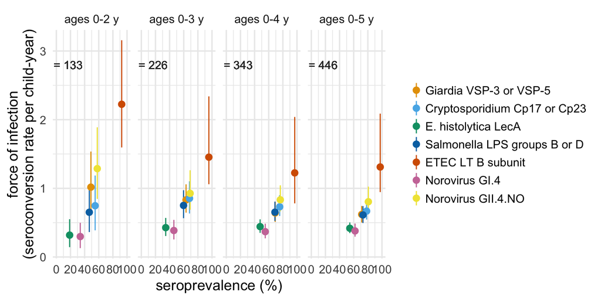

```r
# create more informative age group labels
scr_byage2 <- scr_byage %>%
  mutate(
    agecat= case_when(
    maxage == 2 ~ "ages 0-2 y",
    maxage == 3 ~ "ages 0-3 y",
    maxage == 4 ~ "ages 0-4 y",
    maxage == 5 ~ "ages 0-5 y"),
    nlab = paste("n = ",n,sep="")
    )

# custom color blind color palette is in the preamble chunck
pcols <- cbPalette[c(2:4,6:8,5)]


scr_serop_byage_p <- ggplot(data=scr_byage2,aes(x=seroprev,y=seroi,color=antigenf,fill=antigenf))+
  facet_grid(.~agecat)+
  geom_pointrange(aes(ymin=seroi_lb,ymax=seroi_ub))+
  geom_text(aes(x=0.1,y=2.8,label=nlab),color="gray20")+
  scale_y_continuous(breaks=0:3)+
  scale_x_continuous(breaks=seq(0,1,by=0.2),labels=sprintf("%1.0f",seq(0,1,by=0.2)*100))+
  scale_color_manual(values=pcols)+
  scale_fill_manual(values=pcols)+
  labs(x="seroprevalence (%)",y="force of infection\n(seroconversion rate per child-year)")+
  coord_cartesian(xlim=c(0,1))+
  theme_minimal(base_size=14) +
  theme(
    legend.title=element_blank()
  )

scr_serop_byage_p
```

# Save incidence estimates

```r
saveRDS(rate_ests,file=here::here("output","haiti-enteric-ab-ests-incidencerates.rds"))
saveRDS(rate_ests_4fold,file=here::here("output","haiti-enteric-ab-ests-incidencerates-4fold.rds"))
saveRDS(d_serop,file=here::here("output","haiti-enteric-ab-ests-seroprev-vs-rates.rds"))
saveRDS(scr_byage2,file=here::here("output","haiti-enteric-ab-ests-seroprev-vs-rates-byage.rds"))
```